# Regression Trees

Irfan Kanat

August 3, 2018

# Regression Trees

The multiple regression is great if you can capture the data generating mechanism with a global model. A global model applies to the whole of the data. If you believe certain bits of data are generated with a different process (e.g. Luxury condos have a different slope for square footage), the model starts getting complicated. You would have to introduce interaction terms to take into account these differences. For a limited number of variables this is easy to do, it gets complicated real fast once the number of variables start growing. If you are not married to the idea of a global model, and are more interested in prediction then you can use a regression tree.

You can think of it as partitioning the dataset into smaller subsets. Smaller, well behaved subsets for which we can fit simple models. Once you start going in this direction, you can see that the partitioning is similar to the [20 questions game](http://www.20q.net/). The questions can be thought of as branches in a tree. Each question determines which branch you will be following. By following the branches, you will eventually come to a leaf. For the leaf (subset of data) we will fit a simple model (like the mean) and get a result.

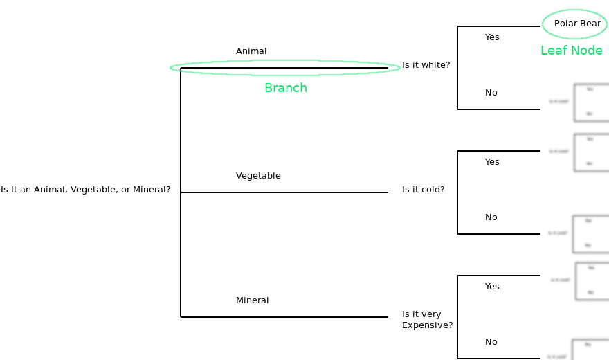

Obviously the order of questions matter. If you were to ask “Is it white” as the first question the resulting split may have been much less effective than asking if it is an animal or a vegetable. What the algorithm does is find the most significant predictor for a split at each brand and split the data based on that predictor. So you can gather the importance of variables by their position on the tree.

A regression tree works in a similar fashion, each question would be about the value of an independent variable. Based on values of independent values we will drill down further and create a manageable subset for which a simple model (such as the mean) would fit.

There are certain advanteges to a regression tree model. It is often easier for humans to make sense of than an equivalent regression model. Trees may fit certain datasets better depending on how the mechanism creating the data works. The algorithms used are computationally simple and efficient.

Let us see how this works over an example:

## UCLA Housing Data

We will be using the UCLA housing data for this exercise. The data can be found among [Kaggle datasets online](https://www.kaggle.com/apratim87/housingdata).

Import the dataset.

```r
housing <- read.csv("data/housingdata.csv")
```

The data is at town level.

CRIM: Crime Rate ZN: Proportion of residential land zoned INDUS: Non-retail business acres per town CHAS: River boundary NOX: Nitric oxide concentration RM: Average number of rooms AGE: Proportion of owner occupied units built before 1940 DIS: Distance to five employment centres RAD: Accessibility to highway TAX: Property tax PTRATIO: Pupil-Teacher Ratio B: Proportion of blacks LSTAT: proportion of lower status MEDV: Median value of homes

## Analysis

First order of business is to establish the partitioning scheme. We will use **rpart** function from **rpart** package.

```r
housing_rt_0 <- rpart(MEDV ~ CRIM + DIS + TAX, data = housing, method = "anova")
```

I won’t go over the parameters of this function call, as most of it should be obvious by now. The only parameter that may be unknown is **method = “anova”**, this is how we tell rpart that we aim to model a continuous variable. If you are curious read the manual for rpart (?rpart).

If we were to call summary over housing_rt_0 we would get a very verbose description of a regression tree. *Try it on your own and inspect the output.*

Let us look at our tree.

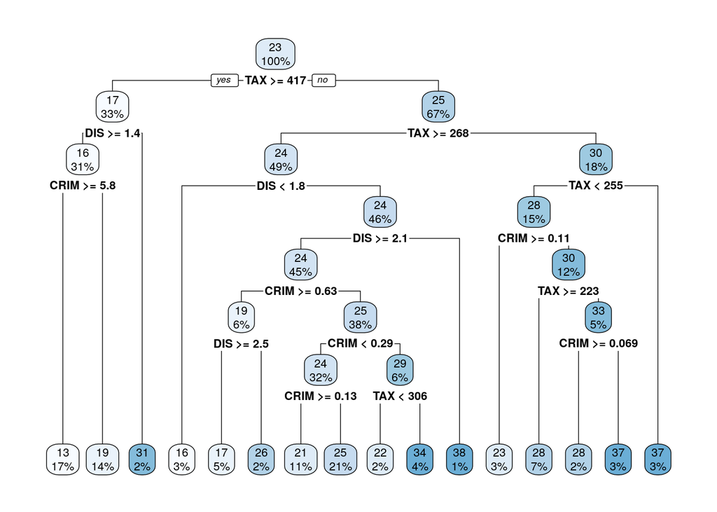

```r
rpart.plot(housing_rt_0)
```

## Pruning the Tree

What I hope you can quickly see upon inspection is that such a tree would defeat the purpose of fitting a regression tree. (1) It would be quite complex (especially considering we are using just three independent variables), so it is not easier to understand or to explain. (2) It is most likely overfitted. That means while it would explain this dataset very well but, it will not be as useful in explaining future datasets.

We need to prune the tree for it to be useful beyond this dataset. For each branch we add, we are adding complexity to the model. The idea is to stop at the point where the added complexity does not justify the added explanatory power. We determine the number of splits using a cp (complexity parameter) table such as the one below:

```r
summary(housing_rt_0, "cp")
```

```
## Call:
## rpart(formula = MEDV ~ CRIM + DIS + TAX, data = housing, method = "anova")
##   n= 506
##
##            CP nsplit rel error    xerror       xstd
## 1  0.20175168      0 1.0000000 1.0025582 0.08317398
## 2  0.06086100      1 0.7982483 0.8166114 0.08092698
## 3  0.06051234      2 0.7373873 0.8072988 0.07898477
## 4  0.03394935      3 0.6768750 0.7340755 0.06815969
## 5  0.02725080      4 0.6429256 0.7165050 0.06919825
## 6  0.02508340      6 0.5884240 0.7094304 0.07014301
## 7  0.02089070      7 0.5633406 0.6947194 0.06775107
## 8  0.01756861     10 0.5006685 0.6690262 0.06635255
## 9  0.01143558     11 0.4830999 0.6575928 0.06623539
## 10 0.01132199     12 0.4716643 0.6544444 0.06276913
## 11 0.01038854     13 0.4603423 0.6477695 0.06265095
## 12 0.01036600     14 0.4499538 0.6381088 0.06025101
## 13 0.01000000     15 0.4395878 0.6375461 0.06024568
##
## Variable importance
##  TAX CRIM  DIS
##   39   33   28
##
## Node number 1: 506 observations
##   mean=22.53281, MSE=84.41956
```

rel error is ($1-R^2$) the ratio of unexplained variance.

xerror is cross validation error.

xstd is cross validation standard deviation.

Ideally you would like errors to be small. We will learn more about cross-validation later but, for now think of it as how well will this model work on other datasets.

There are a number of ways to determine the number of splits. You need to make an honest judgment call on what works best in the given circumstances.

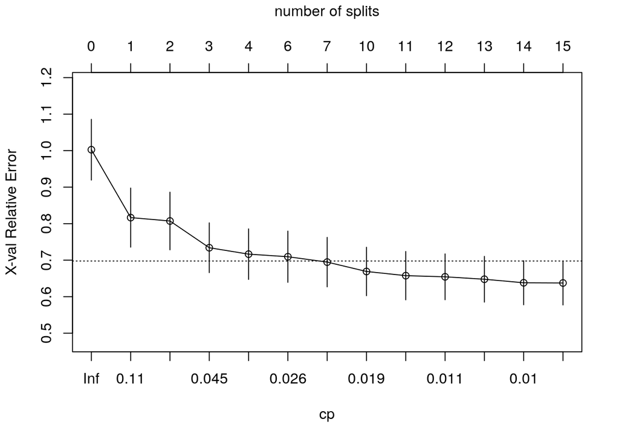

```r
plotcp(housing_rt_0, upper = "splits")
```

Now you can use either the cp of the said model to prune the tree.

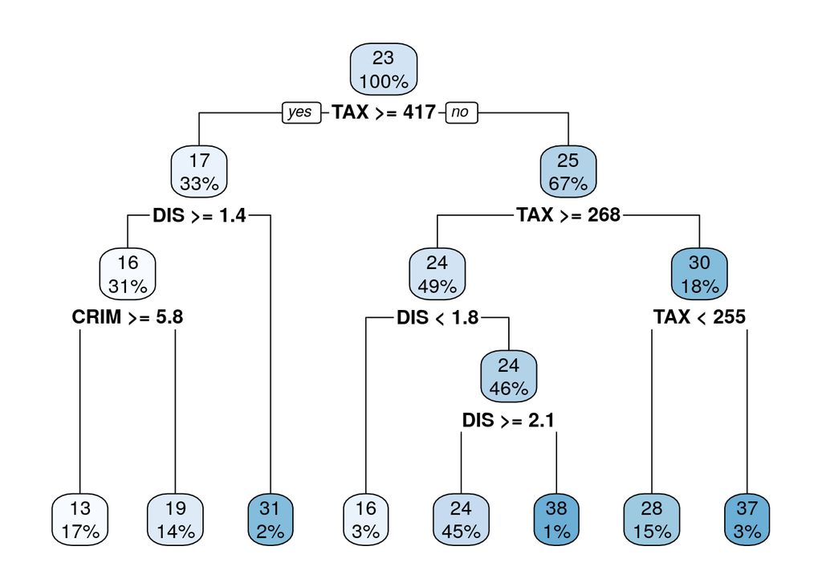

```r
housing_rt_0pr <- prune(housing_rt_0, cp = 0.0209)
rpart.plot(housing_rt_0pr)
```

Now that is more like it.

## Predicting with A Regression Tree